# Voice-hearing, inner speech, and absorption

Eleanor Schille-Hudson

2025-02-05

This rmd file contains analyses for the manuscript *Voice-hearing, inner speech, and absorption: the role of an experiential orientation to the mind* which examines the relationship between inner speech, absorption, and voice hearing in two studies. In Study 1, surveys were administered to undergraduates across five countries (total N = 825). In Study 2, surveys were administered to participants in the US via the online survey platform Prolific (N = 1000).

# Study 1

In packet 1, participants filled out the absorption scale and spiritual events items in all five countries. (N=519)

In packet 2, participants filled out both the Launay-Slade voice hearing scale and the VISQ inner voice scale in all five countries (McCarthy-Jones & Fernyhough; only dialogic, evaluative, and other people subscales–did not include condensed speech!). (N=523)

N = 217 participants completed both packets 1 and 2 together. For these participants, we have their absorption, VISQ, and Launay-Slade scores. These participants were only in the US, Ghana, and China.

## Figure 1

Fig. 1 from the manuscript shows the relationship between inner speech (measured by the VISQ dialogic subscale) and voice hearing (measured by the five auditory items of the revised Launay-Slade scale) in N=523 undergraduates in five countries. The second figure here is not in the manuscript, but shows the positive relationship between voice hearing and all 3 VISQ subscales.

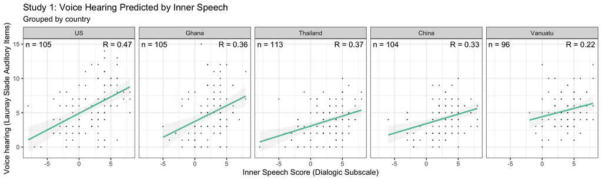

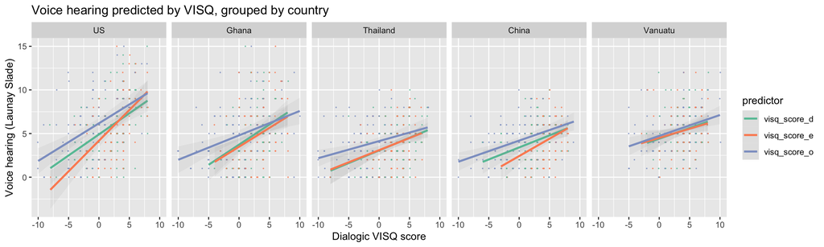

## Table 1

```
##
## Call:
## lm(formula = scale(ls_score, scale = T) ~ 1 + scale(visq_score_d,
##     scale = T) * country, data = dp2_small)
##
## Residuals:
##     Min      1Q  Median      3Q     Max
## -2.3407 -0.6173 -0.0766  0.5528  3.7027
##
## Coefficients:
##                                           Estimate Std. Error t value Pr(>|t|)
## (Intercept)                                0.02093    0.04080   0.513  0.60825
## scale(visq_score_d, scale = T)             0.34545    0.04235   8.157 2.66e-15
## country_gh                                 0.03493    0.07954   0.439  0.66074
## country_th                                -0.34027    0.07733  -4.400 1.31e-05
## country_ch                                -0.23410    0.07969  -2.938  0.00346
## country_vt                                 0.08192    0.09030   0.907  0.36472
## scale(visq_score_d, scale = T):country_gh  0.10860    0.08759   1.240  0.21559
## scale(visq_score_d, scale = T):country_th -0.05988    0.07731  -0.774  0.43902
## scale(visq_score_d, scale = T):country_ch -0.07368    0.08362  -0.881  0.37863
## scale(visq_score_d, scale = T):country_vt -0.10590    0.10071  -1.052  0.29351
##
## (Intercept)
## scale(visq_score_d, scale = T)            ***
## country_gh
## country_th                                ***
## country_ch                                **
## country_vt
## scale(visq_score_d, scale = T):country_gh
## scale(visq_score_d, scale = T):country_th
## scale(visq_score_d, scale = T):country_ch
## scale(visq_score_d, scale = T):country_vt
## ---
## Signif. codes:  0 '***' 0.001 '**' 0.01 '*' 0.05 '.' 0.1 ' ' 1
##
## Residual standard error: 0.9008 on 513 degrees of freedom
## Multiple R-squared:  0.2026, Adjusted R-squared:  0.1886
## F-statistic: 14.48 on 9 and 513 DF,  p-value: < 2.2e-16
```

## Figure 2

Fig. 2 from the manuscript shows N=217 participants’ reports of voice-hearing experiences (Launay-Slade scores) plotted against rescaled scores of inner speech (dialogic subscore of VISQ) and absorption. Inner speech and absorption are predictive of voice hearing across diverse cultural settings.

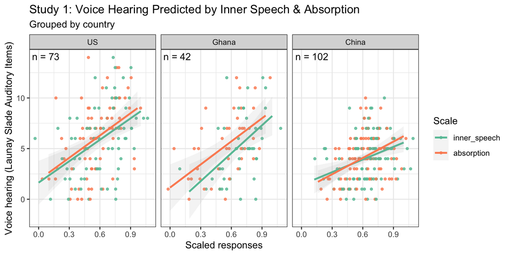

Across samples of undergraduates collected in the US, Ghana, and China (N=217), scores on the revised Launay-Slade Hallucinations scale were positively correlated with dialogic VISQ scores ($\beta$ = 0.45, p<0.001)

## Table 2

```
##
## Call:
## lm(formula = scale(voice_hearing_launayslade, scale = T) ~ 1 +
##     scale(inner_speech, scale = T) * country, data = df123)
##
## Residuals:
##      Min       1Q   Median       3Q      Max
## -2.29185 -0.63591 -0.01544  0.56781  2.39074
##
## Coefficients:
##                                             Estimate Std. Error t value
## (Intercept)                                   0.4021     0.1038   3.873
## scale(inner_speech, scale = T)                0.4478     0.0882   5.076
## countryGhana                                 -0.4063     0.1724  -2.357
## countryChina                                 -0.6877     0.1356  -5.074
## scale(inner_speech, scale = T):countryGhana   0.1361     0.1755   0.775
## scale(inner_speech, scale = T):countryChina  -0.1827     0.1320  -1.384
##                                             Pr(>|t|)
## (Intercept)                                 0.000143 ***
## scale(inner_speech, scale = T)              8.43e-07 ***
## countryGhana                                0.019334 *
## countryChina                                8.53e-07 ***
## scale(inner_speech, scale = T):countryGhana 0.438944
## scale(inner_speech, scale = T):countryChina 0.167875
## ---
## Signif. codes:  0 '***' 0.001 '**' 0.01 '*' 0.05 '.' 0.1 ' ' 1
##
## Residual standard error: 0.8791 on 211 degrees of freedom
## Multiple R-squared:  0.2451, Adjusted R-squared:  0.2272
## F-statistic:  13.7 on 5 and 211 DF,  p-value: 1.376e-11
```

and absorption scores ($\beta$=0.48, p<0.001; these standardized beta coefficients and p-values come from separate regression models for each predictor, each including main effects and interactions with country).

## Table 3

```
##
## Call:
## lm(formula = scale(voice_hearing_launayslade, scale = T) ~ 1 +
##     scale(absorption, scale = T) * country, data = df123)
##
## Residuals:
##      Min       1Q   Median       3Q      Max
## -1.92204 -0.55519  0.00886  0.49833  2.98761
##
## Coefficients:
##                                           Estimate Std. Error t value Pr(>|t|)
## (Intercept)                                0.38741    0.10227   3.788 0.000198
## scale(absorption, scale = T)               0.47927    0.09775   4.903 1.88e-06
## countryGhana                              -0.19401    0.17058  -1.137 0.256673
## countryChina                              -0.72071    0.13470  -5.351 2.28e-07
## scale(absorption, scale = T):countryGhana  0.01742    0.15404   0.113 0.910076
## scale(absorption, scale = T):countryChina -0.12798    0.13874  -0.922 0.357325
##
## (Intercept)                               ***
## scale(absorption, scale = T)              ***
## countryGhana
## countryChina                              ***
## scale(absorption, scale = T):countryGhana
## scale(absorption, scale = T):countryChina
## ---
## Signif. codes:  0 '***' 0.001 '**' 0.01 '*' 0.05 '.' 0.1 ' ' 1
##
## Residual standard error: 0.8685 on 211 degrees of freedom
## Multiple R-squared:  0.2631, Adjusted R-squared:  0.2456
## F-statistic: 15.07 on 5 and 211 DF,  p-value: 1.197e-12
```

We also note that absorption is a predictor of spiritual experiences of all kinds (Luhrmann, Weisman, et al., 2021). In particular, in Study 1, we found that absorption was a significant predictor of spiritual voice-hearing experiences—namely hearing the voice of God or a spirit with their ears or in their mind ($\beta$=0.25, p<0.001).

## Table 4

```
##
## Call:
## lm(formula = scale(voice_score, scale = T) ~ 1 + scale(abs_score,
##     scale = T) * country, data = dp1_small)
##
## Residuals:
##     Min      1Q  Median      3Q     Max
## -1.9315 -0.4852 -0.1910  0.4480  2.9017
##
## Coefficients:
##                                         Estimate Std. Error t value Pr(>|t|)
## (Intercept)                             0.031533   0.038164   0.826  0.40905
## scale(abs_score, scale = T)             0.250073   0.038688   6.464 2.39e-10
## country_gh                              0.980793   0.078265  12.532  < 2e-16
## country_th                             -0.372994   0.072248  -5.163 3.50e-07
## country_ch                             -0.640612   0.075032  -8.538  < 2e-16
## country_vt                              0.220378   0.082509   2.671  0.00781
## scale(abs_score, scale = T):country_gh  0.083044   0.070200   1.183  0.23738
## scale(abs_score, scale = T):country_th  0.004462   0.081987   0.054  0.95662
## scale(abs_score, scale = T):country_ch -0.098842   0.081649  -1.211  0.22662
## scale(abs_score, scale = T):country_vt  0.010697   0.080952   0.132  0.89493
##
## (Intercept)
## scale(abs_score, scale = T)            ***
## country_gh                             ***
## country_th                             ***
## country_ch                             ***
## country_vt                             **
## scale(abs_score, scale = T):country_gh
## scale(abs_score, scale = T):country_th
## scale(abs_score, scale = T):country_ch
## scale(abs_score, scale = T):country_vt
## ---
## Signif. codes:  0 '***' 0.001 '**' 0.01 '*' 0.05 '.' 0.1 ' ' 1
##
## Residual standard error: 0.8178 on 509 degrees of freedom
## Multiple R-squared:  0.3427, Adjusted R-squared:  0.3311
## F-statistic: 29.49 on 9 and 509 DF,  p-value: < 2.2e-16
```

# Study 2

Study 2 is preregistered at https://osf.io/nr9w4

Summary of participants by gender

```
##                                                  Man
##                                                  480
##                                                Woman
##                                                  470
## Something else (Please feel free to say more below.)
##                                                   22
##                                                 NA's
##                                                    3
```

Summary of participants by age

```
##    Min. 1st Qu.  Median    Mean 3rd Qu.    Max.    NA's
##   18.00   28.00   35.00   38.07   46.00   85.00       1
```

Summary of participants by race

```
##                                                              White
##                                                                541
##                                          Black or African American
##                                                                156
##                                               Hispanic or Latina/o
##                                                                 49
##                                                      Central Asian
##                                                                  0
##                                                         East Asian
##                                                                 23
##                                                    Southeast Asian
##                                                                 18
##                                                        South Asian
##                                                                  8
##                                Native Hawaiian or Pacific Islander
##                                                                  1
##                                    Middle Eastern or North African
##                                                                  2
##                 Native American, American Indian, or Alaska Native
##                                                                  2
## Some other race or ethnicity (Please feel free to say more below.)
##                                                                  7
##                                                               NA's
##                                                                168
```

Summary of participants by education

```
##                                Less than high school
##                                                    7
##         High school or equivalent (for example, GED)
##                                                  143
##                                    Vocational degree
##                                                   18
##                                         Some college
##                                                  202
##                          College degree (AA, BA, BS)
##                                                  400
##                                 Some graduate school
##                                                   30
##   Graduate degree (for example, MA, MS, PhD, MD, JD)
##                                                  169
## Something else (Please feel free to say more below.)
##                                                    4
##                                                 NA's
##                                                    2
```

## Preregistered Analyses

### Hypothesis 1

*Inner speech is a significant predictor of voice hearing experiences.*

To test this hypothesis, we will conduct four mixed effects linear regressions, one for each of the three VISQ-R subscales that have been shown to be predictive of voice hearing in past work (namely the evaluative, dialogic, and other people subscales), as well as a regression for the full Revised Varieties of Inner Speech questionnaire (VISQ-R). In all models, the outcome of interest will be the participant’s score on the Launay Slade hallucination scale. The models will use the following regression formula: Launay slade scale ~ 1 + VISQ-R + (1 | subject ID).

*(We note that in our preregistration we intended to run mixed-effects models with random intercepts on participants. This proved untenable as we had the same number of participants as observations. Models were run as regressions using the function lm() in the R package stats.)*

```
##
## Call:
## lm(formula = scale(launayslade_score, scale = T) ~ 1 + scale(visq_full_score,
##     scale = T), data = vrd_scores)
##
## Residuals:
##     Min      1Q  Median      3Q     Max
## -2.2983 -0.6391 -0.0723  0.4956  4.0104
##
## Coefficients:
##                                    Estimate Std. Error t value Pr(>|t|)
## (Intercept)                       0.0001792  0.0284936   0.006    0.995
## scale(visq_full_score, scale = T) 0.4580980  0.0284957  16.076   <2e-16 ***
## ---
## Signif. codes:  0 '***' 0.001 '**' 0.01 '*' 0.05 '.' 0.1 ' ' 1
##
## Residual standard error: 0.8893 on 972 degrees of freedom
##   (1 observation deleted due to missingness)
## Multiple R-squared:   0.21,  Adjusted R-squared:  0.2092
## F-statistic: 258.4 on 1 and 972 DF,  p-value: < 2.2e-16
```

### Hypothesis 2

*Absorption is a significant predictor of voice hearing experiences.*

To test this hypothesis, we will run one mixed effects linear regression in which the outcome of interest will be the participant’s score on the Launay Slade hallucination scale. The model will use the following regression formula: Launay Slade scale ~ 1 + absorption + (1 | subject ID).

```
##
## Call:
## lm(formula = scale(launayslade_score, scale = T) ~ 1 + scale(abs_score,
##     scale = T), data = vrd_scores)
##
## Residuals:
##     Min      1Q  Median      3Q     Max
## -1.8229 -0.6300 -0.1215  0.4936  4.0778
##
## Coefficients:
##                              Estimate Std. Error t value Pr(>|t|)
## (Intercept)                 0.0001267  0.0291670   0.004    0.997
## scale(abs_score, scale = T) 0.4148442  0.0291683  14.222   <2e-16 ***
## ---
## Signif. codes:  0 '***' 0.001 '**' 0.01 '*' 0.05 '.' 0.1 ' ' 1
##
## Residual standard error: 0.9103 on 972 degrees of freedom
##   (1 observation deleted due to missingness)
## Multiple R-squared:  0.1723, Adjusted R-squared:  0.1714
## F-statistic: 202.3 on 1 and 972 DF,  p-value: < 2.2e-16
```

We find that hypothesis 2 is confirmed. Absorption is a significant predictor of voice hearing (p<0.001).

### Hypothesis 3

*Inner speech (as measured by VISQ-R) is a mediator of absorption’s effect on voice hearing.*

We will conduct two sets of mediation analyses using the psych package in R (which bootstraps confidence intervals). The first set will include Absorption as the predictor, the outcome of interest will be the participant’s score on the Launay Slade hallucination scale, and the mediating variable will be the participants’ Inner Speech score as measured by the VISQ-R. In this set of mediation analyses, we will conduct four analyses total, one for each of the three VISQ-R subscales of interest and one for the full VISQ-R score. The models will use the following formula: psych::mediate(Launay Slade ~ (VISQ-R) + Absorption). These mediation analyses will be considered consistent with our hypothesis in the case that the indirect effect is significant. This will be evaluated via the psych package’s significance testing of the bootstrapped indirect effect–meaning that the confidence interval on this effect does not include 0. In the second set of analyses, everything will be kept the same, except the role of predictor and mediator will be reversed. This is in order to determine which direction of mediation is most consistent with the data collected. The models will use the following formula: psych::mediate(Launay Slade ~ (Absorption) + VISQ-R). We will evaluate these models as *not* consistent with our hypothesis by once again using the psych package’s significance testing of the bootstrapped indirect effect. We hypothesize that the confidence intervals on this effect will include 0.

Output here includes Figure 4 from the manuscript.

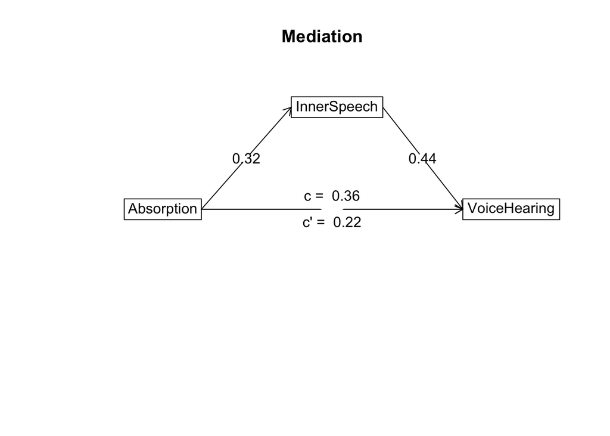

```
##
## Mediation/Moderation Analysis
## Call: psych::mediate(y = VoiceHearing ~ (InnerSpeech) + Absorption,
##     data = df_scored_scales)
##
## The DV (Y) was  VoiceHearing . The IV (X) was  Absorption . The mediating variable(s) =  InnerSpeech .
##
## Total effect(c) of  Absorption  on  VoiceHearing  =  0.36   S.E. =  0.03  t  =  14.24  df=  973   with p =  6.3e-42
## Direct effect (c') of  Absorption  on  VoiceHearing  removing  InnerSpeech  =  0.22   S.E. =  0.03  t  =  7.95  df=  972   with p =  5.2e-15
## Indirect effect (ab) of  Absorption  on  VoiceHearing  through  InnerSpeech   =  0.14
## Mean bootstrapped indirect effect =  0.14  with standard error =  0.02  Lower CI =  0.11    Upper CI =  0.18
## R = 0.51 R2 = 0.26   F = 169.36 on 2 and 972 DF   p-value:  2.59e-88
##
##  To see the longer output, specify short = FALSE in the print statement or ask for the summary
```

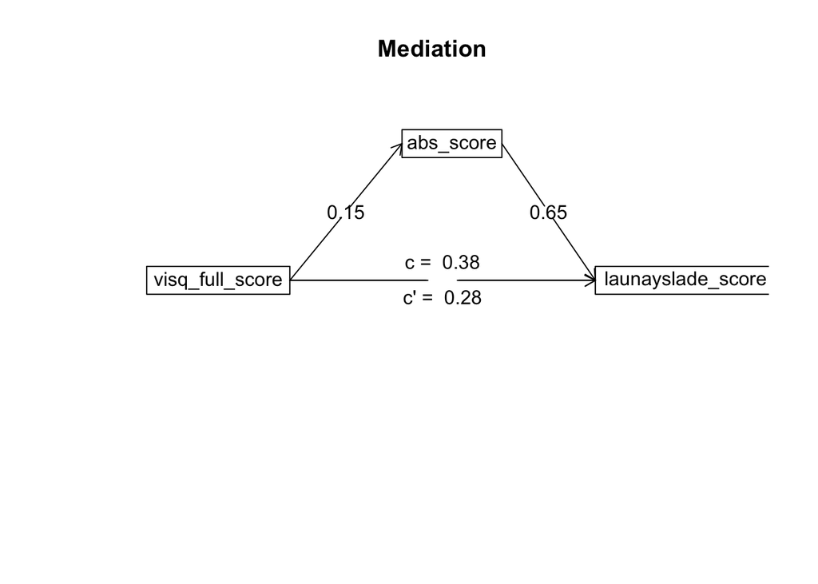

```
##
## Mediation/Moderation Analysis
## Call: psych::mediate(y = launayslade_score ~ (abs_score) + visq_full_score,
##     data = df_scored_scales)
##
## The DV (Y) was  launayslade_score . The IV (X) was  visq_full_score . The mediating variable(s) =  abs_score .
##
## Total effect(c) of  visq_full_score  on  launayslade_score  =  0.38   S.E. =  0.02  t  =  16.09  df=  973   with p =  7.6e-52
## Direct effect (c') of  visq_full_score  on  launayslade_score  removing  abs_score  =  0.28   S.E. =  0.03  t  =  10.62  df=  972   with p =  5.5e-25
## Indirect effect (ab) of  visq_full_score  on  launayslade_score  through  abs_score   =  0.1
## Mean bootstrapped indirect effect =  0.1  with standard error =  0.01  Lower CI =  0.08    Upper CI =  0.13
## R = 0.51 R2 = 0.26   F = 169.36 on 2 and 972 DF   p-value:  2.59e-88
##
##  To see the longer output, specify short = FALSE in the print statement or ask for the summary
```

The second part of hypothesis 3 is not confirmed–absorption appears to be a mediator in all these models.

### Hypothesis 4

*Inner speech and absorption are stronger predictors of spiritual experience than other, less theoretically motivated, predictors.*

To test this hypothesis, we will conduct a set of mixed effects linear regressions in which the outcome of interest will be the participant’s score on the Launay Slade hallucination scale. There will be a total of four regressions, one for each of the VISQ-R subscales and one for the full VISQ-R scale. In each regression, the model will include the following fixed effects: (1) predictor (a 4-level categorical variable encoding the difference between our 4 candidate predictors: scores on the Inner speech scale, Absorption scale, Need for Cognition scale, and Sense of Control, Mastery subscale), score on predictor measure, and all possible interactions. The variable “Predictor” will be coded with the following planned orthogonal contrasts: (A) predictors of interest (Inner speech, Absorption) vs. control scales (Need for Cognition, Sense of Control); (B); measures of inner speech vs. absorption; (C) Need for Cognition vs. Sense of Control. The parameter of primary interest will be the interaction between Predictor Contrast A and Predictor Score, which tests whether our predictors of interest were better predictors of spiritual experience than our control measures were.

```
##
## Call:
## lm(formula = scale(launayslade_score, scale = T) ~ 1 + predictors *
##     predictor_scores, data = df_full_long)
##
## Residuals:
##     Min      1Q  Median      3Q     Max
## -2.2992 -0.7410 -0.1103  0.5667  4.1470
##
## Coefficients:
##                               Estimate Std. Error t value Pr(>|t|)
## (Intercept)                   -0.68177    0.04133 -16.498  < 2e-16 ***
## predictors_A                  -0.52278    0.04133 -12.650  < 2e-16 ***
## predictors_B                  -0.16334    0.06305  -2.590  0.00962 **
## predictors_C                   0.10343    0.05344   1.936  0.05298 .
## predictor_scores               1.44865    0.08054  17.987  < 2e-16 ***
## predictors_A:predictor_scores  1.02866    0.08054  12.773  < 2e-16 ***
## predictors_B:predictor_scores  0.63300    0.12333   5.133    3e-07 ***
## predictors_C:predictor_scores -0.32349    0.10361  -3.122  0.00181 **
## ---
## Signif. codes:  0 '***' 0.001 '**' 0.01 '*' 0.05 '.' 0.1 ' ' 1
##
## Residual standard error: 0.9488 on 3888 degrees of freedom
##   (4 observations deleted due to missingness)
## Multiple R-squared:  0.1014, Adjusted R-squared:  0.09973
## F-statistic: 62.64 on 7 and 3888 DF,  p-value: < 2.2e-16
```

The interaction between Predictor A and Predictor Score, which tests whether our predictors of interest were better predictors of spiritual experience than our control measures were, is the key outcome of interest.

## Study 2 Figures

### Figure 3

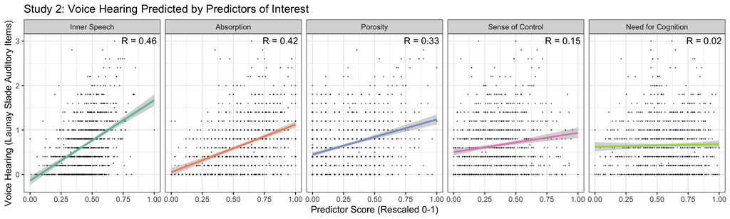

### Figure 5

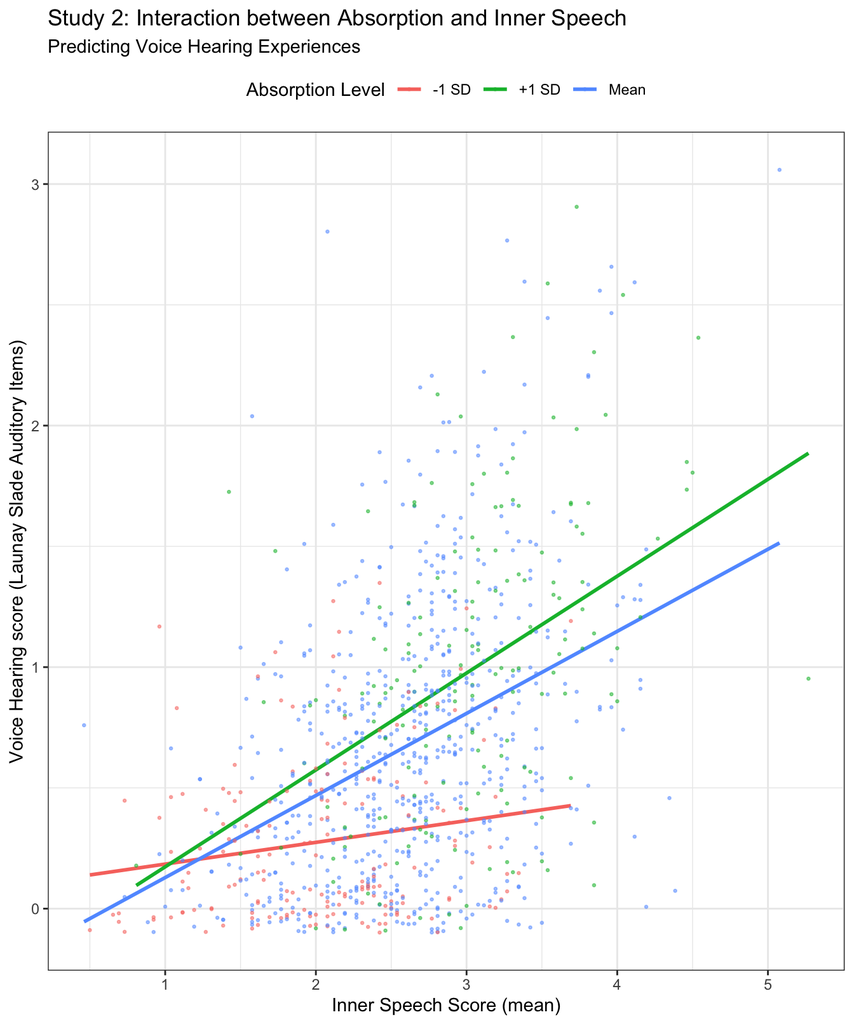

## Exploratory Analyses (not preregistered)

### Correlation between Porosity and Voice Hearing

```
##
## Call:
## lm(formula = scale(launayslade_score, scale = T) ~ 1 + scale(porosity_score,
##     scale = T), data = vrd_scores)
##
## Residuals:
##     Min      1Q  Median      3Q     Max
## -2.0778 -0.7744 -0.0864  0.5656  3.5592
##
## Coefficients:
##                                  Estimate Std. Error t value Pr(>|t|)
## (Intercept)                      0.002704   0.030338   0.089    0.929
## scale(porosity_score, scale = T) 0.325211   0.030358  10.712   <2e-16 ***
## ---
## Signif. codes:  0 '***' 0.001 '**' 0.01 '*' 0.05 '.' 0.1 ' ' 1
##
## Residual standard error: 0.9458 on 970 degrees of freedom
##   (3 observations deleted due to missingness)
## Multiple R-squared:  0.1058, Adjusted R-squared:  0.1049
## F-statistic: 114.8 on 1 and 970 DF,  p-value: < 2.2e-16
```

### Interaction between Inner Speech and Absorption

```
##
## Call:
## lm(formula = scale(launayslade_score, scale = T) ~ 1 + scale(visq_full_score,
##     scale = T) * scale(abs_score, scale = T), data = vrd_scores)
##
## Residuals:
##     Min      1Q  Median      3Q     Max
## -2.1910 -0.5932 -0.1110  0.4802  4.1592
##
## Coefficients:
##                                                               Estimate
## (Intercept)                                                   -0.04636
## scale(visq_full_score, scale = T)                              0.33768
## scale(abs_score, scale = T)                                    0.26624
## scale(visq_full_score, scale = T):scale(abs_score, scale = T)  0.09554
##                                                               Std. Error
## (Intercept)                                                      0.03009
## scale(visq_full_score, scale = T)                                0.03143
## scale(abs_score, scale = T)                                      0.03168
## scale(visq_full_score, scale = T):scale(abs_score, scale = T)    0.02533
##                                                               t value Pr(>|t|)
## (Intercept)                                                    -1.541 0.123717
## scale(visq_full_score, scale = T)                              10.742  < 2e-16
## scale(abs_score, scale = T)                                     8.404  < 2e-16
## scale(visq_full_score, scale = T):scale(abs_score, scale = T)   3.771 0.000172
##
## (Intercept)
## scale(visq_full_score, scale = T)                             ***
## scale(abs_score, scale = T)                                   ***
## scale(visq_full_score, scale = T):scale(abs_score, scale = T) ***
## ---
## Signif. codes:  0 '***' 0.001 '**' 0.01 '*' 0.05 '.' 0.1 ' ' 1
##
## Residual standard error: 0.8564 on 970 degrees of freedom
##   (1 observation deleted due to missingness)
## Multiple R-squared:  0.2689, Adjusted R-squared:  0.2667
## F-statistic: 118.9 on 3 and 970 DF,  p-value: < 2.2e-16
```

### Moderated mediation model

```
## lavaan 0.6-19 ended normally after 8 iterations
##
##   Estimator                                         ML
##   Optimization method                           NLMINB
##   Number of model parameters                         7
##
##                                                   Used       Total
##   Number of observations                           974         975
##
## Model Test User Model:
##
##   Test statistic                                23.369
##   Degrees of freedom                                 2
##   P-value (Chi-square)                           0.000
##
## Parameter Estimates:
##
##   Standard errors                            Bootstrap
##   Number of requested bootstrap draws             1000
##   Number of successful bootstrap draws            1000
##
## Regressions:
##                       Estimate  Std.Err  z-value  P(>|z|)   Std.lv  Std.all
##   visq_full_score ~
##     abs_score (a1)       0.488    0.030   16.234    0.000    0.488    0.488
##   launayslade_score ~
##     vsq_fll_s (b1)       0.338    0.035    9.523    0.000    0.338    0.335
##     abs_score (c1)       0.266    0.031    8.673    0.000    0.266    0.264
##     vsq_fl_:_ (b2)       0.096    0.026    3.742    0.000    0.096    0.104
##
## Variances:
##                    Estimate  Std.Err  z-value  P(>|z|)   Std.lv  Std.all
##    .visq_full_scor    0.762    0.038   19.864    0.000    0.762    0.762
##    .launayslad_scr    0.730    0.042   17.500    0.000    0.730    0.720
##     vsq_fll_scr:b_    1.202    0.111   10.838    0.000    1.202    1.000
##
## Defined Parameters:
##                    Estimate  Std.Err  z-value  P(>|z|)   Std.lv  Std.all
##     Indirect          0.165    0.020    8.088    0.000    0.165    0.163
##     Direct            0.266    0.031    8.669    0.000    0.266    0.264
##     Total             0.431    0.029   14.979    0.000    0.431    0.428
```

### Prevalence of voice hearing

The proportion of participants who responded more than ‘never’ to at least one Launay-Slade item:

```
## [1] 0.7876923
```

The proportion of participants who responded more than ‘never’ to at least one Posey Losch item:

```
## [1] 0.9035897
```

The proporiton of participants who responded more than ‘never’ to at least one spiritual voice question:

```
## [1] 0.4266667
```